# Computing lab: Data mangling basics on wildfire data

North-South-AIMS-Imperial: modern statistics and global health

Shozen Dan and Oliver Ratmann

# 1 Study objectives

Hello all!

The objectives of this lab are to become familiar with basic data mangling functions (merge, melt, ggplot) and basic epidemiologic measures (incidence and prevalence).

Let us look at a large, real data set, 1.88 million geo-referenced wildfires in the US that were reported to the national Fire Program Analysis system. [The data set is reported here on Kaggle in detail](https://www.kaggle.com/rtatman/188-million-us-wildfires).

One more tip before we dive in: visit the [RStudio cheatsheet website](https://rstudio.com/resources/cheatsheets/) and download any cheat sheet that you might find useful. For the below, those on `date and time conversion`, `data.table`, and `ggplot` might be particularly helpful.

This work is licensed under a [Creative Commons Attribution-NonCommercial-NoDerivatives 4.0 International License](https://creativecommons.org/licenses/by-nc-nd/4.0/).

## 1.1 Objective 1

The first objective is to calculate the `incidence proportion` of US land area in which a new fire occured in 2010-2011. In general, the incidence proportion is the number of new cases observed in a population at risk during a particular study period. With population at risk, we usually mean only those individuals or units that can become a case, so for example water area is excluded when we consider wildfires, or men are excluded when we consider ovary cancer.

So, we need to

- calculate the denominator, the US land area (i.e. exclude water area); and
- calculate the numerator, the US land area in which a new fire occurred in the period 2010-2011; and
- then take the ratio.

## 1.2 Objective 2

The second task is to calculate the `point prevalence` of US land area subject to ongoing wildfire devastation in each month in 2010-2011. In general, the point prevalence quantifies the proportion of existing cases in a population at a given time. Again, we usually mean only those individuals or units that can become a case, so for example water area is excluded in the denominator when we consider wildfires, or men are excluded when we consider ovary cancer.

You need to

- calculate the denominator, the US land area (i.e. exclude water area); and
- calculate the numerator, the US land area that was subject to ongoing/existing wildfire devastation in each month; and
- take the ratio.

## 1.3 Objective 3

The third and final task is to plot US wildfire prevalence over time.

## 1.4 Other things

Along the way, we will also:

- read from a `SQLite` database and store parts of the data as a `data.table`. If you are not familiar with `data.tables` revisit some online tutorials. Throughout, we here use the `data.table` package, which brings substantial efficiency gains when processing large data sets; and
- make basic data transformations with the `data.table` package, like taking subsets and selecting columns; and
- combine `data.tables` with the `merge` function; and
- introduce more complex `data.table` operations that act simultaneously on subsets of rows, and replace traditional `for loops`; and
- show you how to process dates in the `Date` class; and
- cover the `melt` function in the the `data.table` package.

# 2 Load packages

```r
# install.packages('RSQLite')
require(RSQLite)
require(DBI)
require(dbplyr)
require(data.table)  # data mangling
require(tidyverse)  # data mangling
require(knitr)
require(kableExtra)
require(formatR)

data.dir <- "/Users/tb23243/Library/CloudStorage/OneDrive-ImperialCollegeLondon/AIMS-Imperial-workshop/practicals/practical_2_gps/data"
out.dir <- "/Users/tb23243/Library/CloudStorage/OneDrive-ImperialCollegeLondon/AIMS-Imperial-workshop/practicals/practical_2_gps/outputs"
```

# 3 Data analysis

## 3.1 Reading SQLite wildfire data into RDS format

The code below reads parts of an `SQLite` wildfire data base and stores it in the traditional `RDS` format.

```r
#
# tutorial for interacting with SQLite
# https://datacarpentry.org/R-ecology-lesson/05-r-and-databases.html
#

# I downloaded the database from the above Kaggle link,
# https://www.kaggle.com/rtatman/188-million-us-wildfires
# and stored it in the file
file <- file.path(data.dir,'FPA_FOD_20170508.sqlite')

# open SQLite database
db_wf <- DBI::dbConnect(RSQLite::SQLite(), file)

# list tables and columns
dbplyr::src_dbi(db_wf)

# read "fire" table and show column names
wf <- dplyr::tbl(db_wf, sql("SELECT * FROM fires"))
colnames(wf)

# select columns
# use the pipe command %>% that was introduced in the magrittr package
# use collect to gather all rows from the SQLite data base
# and store in a standard R object
wf <- wf %>%
  select(OBJECTID, FOD_ID, LATITUDE, LONGITUDE, STATE,
         COUNTY, FIPS_CODE, FIRE_YEAR, DISCOVERY_DOY,
         FIRE_SIZE) %>%
  collect()

# convert to data.table because of size of data, and save
wf <- as.data.table(wf)
setnames(wf, 'DISCOVERY_DOY', 'DISCOVERY_DAY')
saveRDS(wf, file=file.path(data.dir, 'FPA_FOD_20170508_fires.RDS'))
DBI::dbDisconnect(db_wf)
```

## 3.2 Merge state land area in square miles

The code below illustrates basic functions for operating with `data.tables`, and in particular the `merge` function. We will use `data.tables` throughout the module because they bring substantial efficiency gains when processing large data sets, so take this opportunity to familiarize yourselves with the package.

```r
wf <- readRDS(file.path(data.dir, 'FPA_FOD_20170508_fires.RDS'))

# inspect the data type of each column
str(wf)

# here are the US land area measurements
file <- file.path(data.dir,'us_states_area_measurements.csv')
wa <- as.data.table(read.csv(file, stringsAsFactors = FALSE))

# The first thing we note is that the wf data.table is using US state abbreviations,
# and the wa data.table is using the full state names.
# so we need to do a bit more work.
# here is a map between state names and state abbreviations
# from https://worldpopulationreview.com/states/state-abbreviations
file <- file.path(data.dir,'us_state_codes.csv')
wc <- as.data.table(read.csv(file, stringsAsFactors = FALSE))

# now we will merge the data.tables so we have land area and wild fires in one data.table
setnames(wa, colnames(wa), toupper(colnames(wa)))
setnames(wc, colnames(wc), toupper(colnames(wc)))
wa <- subset(wa, select=c(STATE, LANDAREA, WATERAREA, TOTALAREA))
wc <- subset(wc, select=c(STATE, CODE))
wa <- merge(wc, wa, by='STATE')
#NOTE the last line is where the magic happens.
#the two data.tables are joint by the key 'STATE'
#be sure to understand how this works.

setnames(wf, 'STATE', 'CODE')
sort(unique(wf$CODE))
sort(unique(wa$CODE))
# shows Puerto Rico not in our codes -- never mind, let s exclude Puerto Rico
wf <- subset(wf, CODE!='PR')
stopifnot( all( sort(unique(wf$CODE))==sort(unique(wa$CODE)) ) )
wf <- merge(wf, wa, by='CODE')
#NOTE the last line is where the magic happens.
#the two data.tables are joint by the key 'STATE'
```

## 3.3 Calculate incidence proportion of US land area subject to wildfire devastation in 2010-2011.

Your first task today is to calculate the `incidence proportion` of US land area in which a new fire occured in the period 2010-2011. Two tips:

- one acre of land corresponds to 0.0015625 square miles.
- the answer should be 0.578%, i.e. approximately 1 in 200 square miles of US land had a new fire occurring in the two years 2010-2011.

```r
# TODO
```

## 3.4 Calculate wildfire prevalence by month

Your second task today is to calculate the point prevalence of US land area subject to ongoing wildfire devastation in each month.

I will first show you how to convert the time columns into a proper `Date` object, and then extract `months`:

```r
# the following post helps us approach the problem:
# https://stackoverflow.com/questions/24200014/convert-day-of-year-to-date

# first add a column that gives the correct 'origin' as in the above post
# to convert to date format
wf[, DUMMY:= paste0(FIRE_YEAR-1,'-12-31')]

# next follow the commands in the above post
wf[, DISCOVERY_DATE:= as.Date(DISCOVERY_DAY, origin=DUMMY)]

# clean up using in-built data.table functions that avoid making deep
# copies of the large data
set(wf, NULL, c('DISCOVERY_DAY','DUMMY'), NULL)

# now it is easy to define the month
wf[, DISCOVERY_MONTH:= strftime(DISCOVERY_DATE, "%m")]
```

To calculate wildfire prevalence, we will additionally assume that each fire lasted 1 week from the discovery date onwards. With this assumption, it is easy to check if a fire was still burning in the following month. We just need to calculate the last day on which the fire burnt.

The following code does these calculations, and introduces the important `melt` function:

```r
wf[, FIRE_LAST_DAY:= DISCOVERY_DATE+7]
wf[, FIRE_LAST_DAY_MONTH:= strftime(FIRE_LAST_DAY, "%m")]

# if fire ends in the same month, then we should not count
# the fire twice (have a look at the melt function below to understand)
wfl_part1 <- subset(wf, DISCOVERY_MONTH==FIRE_LAST_DAY_MONTH)
wfl_part1[, FIRE_LAST_DAY_MONTH:=NULL]

#the magic is now to use the melt function
#the melt function translates a data.table from wide format to long format
#the wide format pertains to the columns DISCOVERY_MONTH and FIRE_LAST_DAY_MONTH
#in the long format will list each fire several times in rows, if it burned over several months
#this means that our prevalence calculation is straightforward when the data is in long format
wfl_part2 <- subset(wf, DISCOVERY_MONTH!=FIRE_LAST_DAY_MONTH)
wfl_part2 <- melt(wfl_part2,
                  measure.vars = c('DISCOVERY_MONTH','FIRE_LAST_DAY_MONTH'),
                  value.name = 'MONTH'
                  )

# adjust for spillover to next year
tmp <- wfl_part2[, which(
  strftime(FIRE_LAST_DAY, "%Y") != strftime(DISCOVERY_DATE, "%Y") &
  variable == "FIRE_LAST_DAY_MONTH"
  )]
set(wfl_part2, tmp, 'FIRE_YEAR', wfl_part2[tmp, as.integer(strftime(FIRE_LAST_DAY, "%Y"))])

# now put everything together
# the end result is a data.table in which a fire occurs twice if it burnt in two months
wfl_part1 <- melt(wfl_part1,
                  measure.vars = c('DISCOVERY_MONTH'),
                  value.name = 'MONTH'
                  )
wfl <- rbind(wfl_part1, wfl_part2)
```

Now it is your turn to calculate the point prevalences.

You should find point prevalences for 288 months, and in magnitude the point prevalences should be much smaller than the incidence proportion over the 2 year period 2010-2011.

```r
# TODO
```

## 3.5 Plot wildfire prevalence by month

Your third and final task is to plot US wildfire prevalence over time. Specifically, plot:

- dates (year and month) on the x-axis
- prevalence on the y-axis
- using `ggplot`, `geom_line`, and `geom_point`

so that you get a plot similar to the one below:

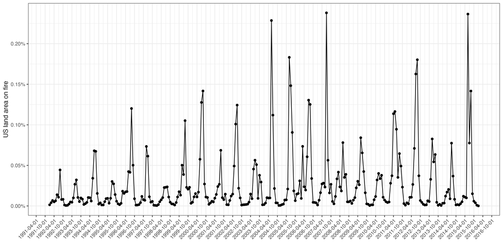

```r
# TODO
```